# Topic modeling-LDA

ADA Analytics

28 de octubre de 2018

## Latent Dirichlet Allocation (LDA)

El modelo creado se encuentra basado en una representación de Topic models, específicamente Latent Dirichlet Allocation LDA. El cual es un modelo de tipo probabilístico.

LDA es un modelo bayesiano de tercer nivel en donde la asociación de términos permite la agrupación de los documentos en tópicos.

## Paquetes

```r
library(knitr)
library(textmineR)
library(tm)
library(stringr)
library(NLP)
library(Matrix)
```

## Lectura de datos

```r
load("~/Dataton2018/Data/df.comp.filtrada.RData")
df.comp<-df.comp2
rm(df.comp2)
```

## Limpieza de datos

Se realizo una limpieza de los valores de tipo texto de la data. Esta limpieza incluye:

*se eliminan espacios en blanco, números y valores especiales.* Se eliminan todos lo “stopword” del español ya que no aportan significado, estos son (de, para ,el, la, etc). *se colocan todas el texto en minuscula para evitar diferencias de palabras por este motivo.* se debe realizar stemming, pir ejemplo pago, pagar, pagos, pagan, etc pasan a ser solo “pago”. *se reemplazaron los valores perdidos NA por espacios en blanco.

Una vez limpuazo los campos de tipo texto concatenan las tres columnas ref1 ref2 y ref3 en un sola.

```r
dataCleaner<-function(text){

  cleanText <- tolower(text)
  cleanText <- removePunctuation(cleanText)
  cleanText <- removeNumbers(cleanText)
  cleanText <- str_replace_all(cleanText, "[^[:alnum:]]", " ")
  cleanText <- str_replace_all(cleanText, "_", " ")
  cleanText <- str_replace_all(cleanText, "na", " ")
  cleanText <- str_replace_all(cleanText, "cc", " ")
  cleanText <- stripWhitespace(cleanText)
  cleanText <- stemDocument(cleanText, language="spanish")


  return(cleanText)
}

df.comp <- transform(df.comp, text = paste(ref1," ", ref2," ", ref3))
df.comp$text2=dataCleaner(df.comp$text)

text2 <- df.comp$text2[1:10000]
```

## Preparación de la data para el modelo LDA

Se genera el documento que contiene los termino en formato matrix.

```r
dtma <- CreateDtm(doc_vec = text2, # vector con los caracteres de tipo texto
                  doc_names = df.comp$id_trn_ach[1:10000], # id de cada texto
                  ngram_window = c(1, 2), # maximo y minomo de bgrams a utilizar
                  stopword_vec = c(tm::stopwords("spanish"),
                                   tm::stopwords("SMART")),
                  lower = TRUE, # lowercase
                  remove_punctuation = TRUE,
                  remove_numbers = TRUE,
                  verbose = FALSE,
                  cpus = 2)
```

## Ajuste del modelo

Para ajustar el modelo se utilizó como Input el documento que contiene los termino en formato matrix, creada anteriormente. En el proceso se crean 100 tópicos que luego se seleccionaran los mas relevantes.

```r
model <- FitLdaModel(dtm = dtma,
                     k = 100,
                     iterations = 1000,
                     alpha = 0.1,
                     beta = 0.05,
                     cpus = 2)
str(model)
```

## Analisis del ajuste del modelo

```r
#R cuadrado
model$r2 <- CalcTopicModelR2(dtm = dtma,
                             phi = model$phi,
                             theta = model$theta,
                             cpus = 2)

#Likelihood
model$ll <- CalcLikelihood(dtm = dtma,
                           phi = model$phi,
                           theta = model$theta,
                           cpus = 2)
```

## Coherecia

Se crea una métrica que analiza la coherencia de los grupos creados, el cual es encuentra basado en teoría probabilística. La coherencia mide que tan asociados se encuentran los valores a un tema, a mayor valor mayor asociación de tema creado las categorías que lo componen. El grafico muestra la coherencia de los 100 tópicos creados.

```r
model$coherence <- CalcProbCoherence(phi = model$phi, dtm = dtma, M = 5)
```

```r
summary(model$coherence)
```

```
##    Min. 1st Qu.  Median    Mean 3rd Qu.    Max.
## -0.1980  0.1612  0.3347  0.3770  0.5694  0.9352
```

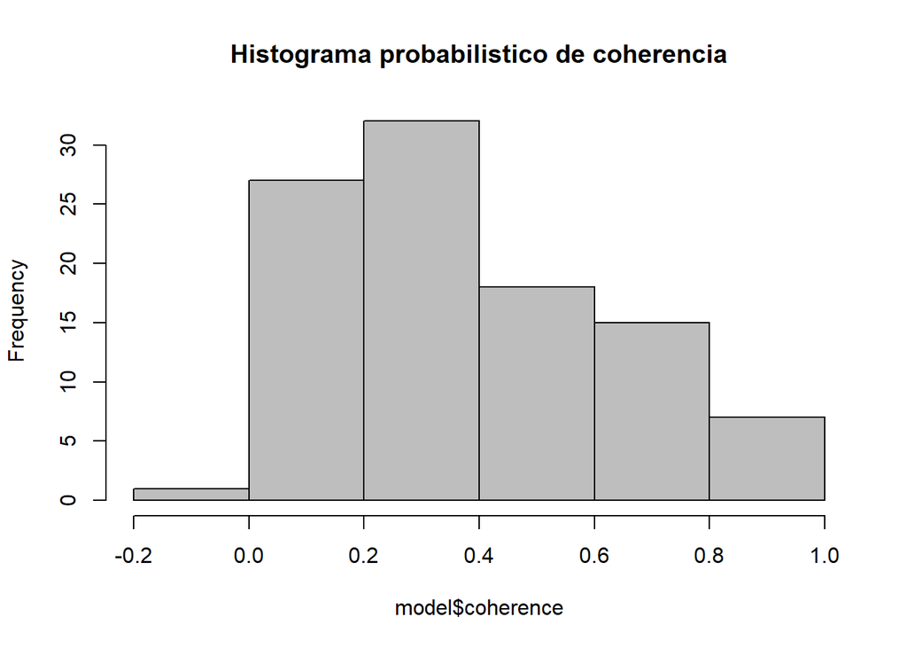

```r
hist(model$coherence,
     col= "grey",
     main = "Histograma probabilistico de coherencia")
```

## Principales terminos de cada grupo

Se indica la inclusión de solo 5 palabras por grupo.

```r
model$top_terms <- GetTopTerms(phi = model$phi, M = 5)
kable(head(model$top_terms))
```

| t_1 | t_2 | t_3 | t_4 | t_5 | t_6 | t_7 | t_8 | t_9 | t_10 | t_11 | t_12 | t_13 | t_14 | t_15 | t_16 | t_17 | t_18 | t_19 | t_20 | t_21 | t_22 | t_23 | t_24 | t_25 | t_26 | t_27 | t_28 | t_29 | t_30 | … |
| --- | --- | --- | --- | --- | --- | --- | --- | --- | --- | --- | --- | --- | --- | --- | --- | --- | --- | --- | --- | --- | --- | --- | --- | --- | --- | --- | --- | --- | --- | --- |
| pag | pag | esp | pag | colegi | pag | conj | compr | credit | pag | paquet | pag | cam | referent | lin | pag_tipific | credit | pag | pag | recarg | idc | pag | pag | pag | pag | compr | pag | cpv | pag | pag | … |
| onlin | pag_eps | public | ahorr | pag_obligacion | valor | res | ce | tarjet | compr | compr_paquet | surameric | cam_comerci | referent_pag | recarg | tipific | tarjet_credit | trav | document | pag_recarg | cart | ce | cedul | vent | tpni | valoriz | virtual | administracin | servici | metrotel | … |
| pag_onlin | eps | medellin_esp | pag_cart | obligacion | pag_electron | conj_res | proc_compr | tarjet_credit | product | compr | pag_surameric | comerci | pag_express | recarg_lin | pag | tarjet | pag_trav | pag_document | sas | cart_idc | esp_ce | arrend | vent_adici | par | medellin | virtual_pasarel | administr | pag_servici | debit | … |
| amway | matricul_tpni | empres | aport | colegi_colomb | electron | bog | proc | card | compr_product | cobr | sorpr | bogot | express | pag_lin | aport_oblig | credit_vis | pag_pse | nit | flytech | facturacion | factur_ce | factur_cedul | adici_cedul | par_dos | medellin_fonvalm | pasarel | asistent_administr | servici_internet | web_metrotel | … |
| onlin_amway | johann | medellin | cart | colomb | factur_valor | ph | lini | mast | deli_reposteri | cedul | herbalif | virtual_cam | pag | compr_lin | aport | vis | trav_pag | document_pag | flytech_sas | mb | pag_mes | pag_arrend | adici | segur_social | valoriz_medellin | rebaj_virtual | sandoval_palaci | internet | nro | … |

# Prevalencia de los grupo

Indica que tan frecuente es un tema en la base de datos.

```r
model$prevalence <- colSums(model$theta) / sum(model$theta) * 100
```

# Etiquetas

Las etiquetas se de formaron automática basadas en bigramas más probable de los grupos, posteriormente se plantea una lectura y recodificación de cada termino.

```r
model$labels <- LabelTopics(assignments = model$theta > 0.05,
                            dtm = dtma,
                            M = 1)

model$summary <- data.frame(topic = rownames(model$phi),
                            label = model$labels,
                            coherence = round(model$coherence, 3),
                            prevalence = round(model$prevalence,3),
                            top_terms = apply(model$top_terms, 2, function(x){
                              paste(x, collapse = ", ")
                            }),
                            stringsAsFactors = FALSE)
```

# Nueva tabla con nuevas etiquetas

La siguiente tabla muestra los nombres de los grupos con su respectivos indicadores de coherencia y prevalencia.

```r
model$summary[ order(model$summary$prevalence, decreasing = TRUE) , ][ 1:10 , ]
```

```
##       topic                                               label_1
## t_37   t_37 ionparageneraciondecertificadosdetradicionylibert_idc
## t_60   t_60                                      referent_contrat
## t_3     t_3                                         empres_public
## t_32   t_32                                            pag_factur
## t_89   t_89                                         empres_public
## t_14   t_14                                          referent_pag
## t_75   t_75                                            pag_factur
## t_64   t_64                                           pag_express
## t_39   t_39                                              pag_sald
## t_100 t_100                                              pag_sald
##       coherence prevalence
## t_37      0.746      3.430
## t_60      0.800      3.264
## t_3       0.935      2.687
## t_32      0.539      2.655
## t_89      0.911      2.531
## t_14      0.602      2.261
## t_75      0.523      2.151
## t_64      0.708      2.050
## t_39      0.150      1.861
## t_100     0.150      1.795
##                                                                                                                                                                           top_terms
## t_37  idc, trans, ionparageneraciondecertificadosdetradicionylibert_idc, trans_ionparageneraciondecertificadosdetradicionylibert, ionparageneraciondecertificadosdetradicionylibert
## t_60                                                                                                                      contrat, referent_contrat, valor, referent, contrat_valor
## t_3                                                                                                                                     esp, public, medellin_esp, empres, medellin
## t_32                                                                                                                               factur, pag_factur, postpag, factur_postpag, pag
## t_89                                                                                                                       empres_public, empres, medellin, public_medellin, public
## t_14                                                                                                                              referent, referent_pag, pag_express, express, pag
## t_75                                                                                                                                       factur, pag_factur, cmr, factur_cmr, pag
## t_64                                                                                                                                        express, ref, ref_pag, pag_express, pag
## t_39                                                                                                                  pag_sald, sald, pag, kjbxw, hebnsrbookingpsepaymentpag_tiquet
## t_100                                                                                                                                           sald, pag_sald, pag, varic, sa_siti
```

```r
cluster<-model$summary[ order(model$summary$prevalence, decreasing = TRUE) , ]
#View(cluster)

kable(head(cluster))
```

|  | topic | label_1 | coherence | prevalence | top_terms |
| --- | --- | --- | --- | --- | --- |
| t_37 | t_37 | ionparageneraciondecertificadosdetradicionylibert_idc | 0.746 | 3.430 | idc, trans, ionparageneraciondecertificadosdetradicionylibert_idc, trans_ionparageneraciondecertificadosdetradicionylibert, ionparageneraciondecertificadosdetradicionylibert |
| t_60 | t_60 | referent_contrat | 0.800 | 3.264 | contrat, referent_contrat, valor, referent, contrat_valor |
| t_3 | t_3 | empres_public | 0.935 | 2.687 | esp, public, medellin_esp, empres, medellin |
| t_32 | t_32 | pag_factur | 0.539 | 2.655 | factur, pag_factur, postpag, factur_postpag, pag |
| t_89 | t_89 | empres_public | 0.911 | 2.531 | empres_public, empres, medellin, public_medellin, public |
| t_14 | t_14 | referent_pag | 0.602 | 2.261 | referent, referent_pag, pag_express, express, pag |

# Prediccion de grupo para cada transaccion

```r
model$phi_prime <- CalcPhiPrime(phi = model$phi,
                                theta = model$theta)

assignments <- dtma / rowSums(dtma)

assignments <- assignments %*% t(model$phi_prime)

assignments <- as.matrix(assignments) # convert to regular R dense matrix

#head(df.comp)
```

# Comparacion de la asociacion creada una transaccion

```r
df.assignments<- as.data.frame(assignments)

colnames(df.assignments)<-model$labels
df.assignments$segment<-colnames(df.assignments)[max.col(df.assignments,ties.method=c("first"))]
df.assignments$id_trn_ach <- rownames(df.assignments)

#datos originales
df.comp[df.comp$id_trn_ach == 226533961, c('text')]
```

```
## [1] Empresas Publicas de Medellin ESP   CC   NA
## 78715 Levels: '   CC   NA ... ZZXMSE  BOGRW   CC   NA
```

```r
#segmento asociado
df.assignments[df.assignments$id_trn_ach == 226533961,  c('segment')]
```

```
## [1] "empres_public"
```

```r
selected <- df.assignments[, cluster[cluster$coherence>0.4,c("label_1")]]

df.assignments$segmentsmall<-colnames(selected)[max.col(selected,ties.method=c("first"))]
df.assignments$id_trn_ach <- rownames(df.assignments)

#datos originales
df.comp[df.comp$id_trn_ach == 226533961, c('text')]
```

```
## [1] Empresas Publicas de Medellin ESP   CC   NA
## 78715 Levels: '   CC   NA ... ZZXMSE  BOGRW   CC   NA
```

```r
#segmento asociado
df.assignments[df.assignments$id_trn_ach == 226533961,  c('segmentsmall')]
```

```
## [1] "empres_public"
```

# Unión de la nueva variable segmento a la base original.

```r
library(dplyr)

myvars <- c("id_trn_ach", "segment","segmentsmall")
df.assignments2 <- df.assignments[myvars]
df.comp2_10000<-left_join(df.comp[1:10000,], df.assignments2, by = c("id_trn_ach"))

#head(table(a$segment2))
```

## Limpieza de la nueva data segmento

Dado el proceso de stemmwords acorta las palabras, se realiza una nueva recodificación de los datos.

```r
df.comp2_10000$segment <-str_replace_all(
  df.comp2_10000$segment,
    c(
      "contract_addreess"="contracto addreess",
      "ionparageneraciondecertificadosdetradicionylibert_idc"="Transaccion idc",
      "trans ionparaconsultaporindicedepropietari"="Transaccion consulta idc",
      "empres_public" = "Empresa Publica",
      "_" = " ",
      "pag" = "Pago",
      "sald"="Saldo",
      "factur"="Factura",
      "electron"="Electronico",
      "servici"="Servicio",
      "recarg"="Recarga",
      "onlin"="Online",
      "compr"="Compra",
      "referent contrat"="Referencia Contrato",
      "tarjet credit"="Tarjeta Credito",
      "cart idc"="Cartera IDC",
      "Pago tipific" = "Pago"
    ))

df.comp2_10000$segmentsmall <-str_replace_all(
  df.comp2_10000$segmentsmall,
    c(
      "contract_addreess"="contracto addreess",
      "ionparageneraciondecertificadosdetradicionylibert_idc"="Transaccion idc",
      "trans ionparaconsultaporindicedepropietari"="Transaccion consulta idc",
      "empres_public" = "Empresa Publica",
      "_" = " ",
      "pag" = "Pago",
      "sald"="Saldo",
      "factur"="Factura",
      "electron"="Electronico",
      "servici"="Servicio",
      "recarg"="Recarga",
      "onlin"="Online",
      "compr"="Compra",
      "referent contrat"="Referencia Contrato",
      "tarjet credit"="Tarjeta Credito",
      "cart idc"="Cartera IDC",
      "Pago tipific" = "Pago"
    ))


condenseMe <- function(vector, threshold = 0.005, newName = "Otros") {
  toCondense <- names(which(prop.table(table(vector)) < threshold))
  vector[vector %in% toCondense] <- newName
  vector
}

df.comp2_10000$segment2<-condenseMe(df.comp2_10000$segment)
```

# Base final

La base final contiene las nuevas variables de segmento basadas en las variables de texto ref1 ref2 y ref3

```r
a<-df.comp2_10000[,c("id_trn_ach","id_cliente","fecha","ref1","ref2","ref3","text","segment","segment2","segmentsmall")]

kable(a[1:20,])
```

| id_trn_ach | id_cliente | fecha | ref1 | ref2 | ref3 | text | segment | segment2 | segmentsmall |
| --- | --- | --- | --- | --- | --- | --- | --- | --- | --- |
| 222356110 | 10 | 2016-10-16 | Referencia: Contrato: Valor: | CC | NA | Referencia: Contrato: Valor: CC NA | Referencia Contrato | Referencia Contrato | Referencia Contrato |
| 309137749 | 10 | 2018-01-20 | CC | NA | NA | CC NA NA | NA | NA | NA |
| 324614737 | 10 | 2018-03-26 | CC | NA | NA | CC NA NA | NA | NA | NA |
| 359125394 | 35 | 2018-08-08 | CPV | NA | NA | CPV NA NA | asistent administr | asistent administr | fc dat |
| 242770525 | 74 | 2017-02-17 | Pago de Saldo | NA | NA | Pago de Saldo NA NA | Pago Saldo | Pago Saldo | Pago Factura |
| 226533961 | 77 | 2016-11-13 | Empresas Publicas de Medellin ESP | CC | NA | Empresas Publicas de Medellin ESP CC NA | Empresa Publica | Empresa Publica | Empresa Publica |
| 369338617 | 77 | 2018-09-14 | Empresas Publicas de Medellin ESP | CC | NA | Empresas Publicas de Medellin ESP CC NA | Empresa Publica | Empresa Publica | Empresa Publica |
| 264659672 | 125 | 2017-06-15 | NA | TPNI | NA | NA TPNI NA | Pago tpni | Pago tpni | trans ionparaconsultaporindicedepropietari |
| 329729396 | 125 | 2018-04-15 | NA | TPNI | NA | NA TPNI NA | Pago tpni | Pago tpni | trans ionparaconsultaporindicedepropietari |
| 334642215 | 125 | 2018-05-04 | NA | TPNI | NA | NA TPNI NA | Pago tpni | Pago tpni | trans ionparaconsultaporindicedepropietari |
| 333626572 | 142 | 2018-05-02 | CC | NA | NA | CC NA NA | NA | NA | NA |
| 333640686 | 142 | 2018-05-02 | CC | NA | NA | CC NA NA | NA | NA | NA |
| 369593322 | 178 | 2018-09-16 | CE | NA | NA | CE NA NA | Pago express | Pago express | Pago express |
| 309271554 | 202 | 2018-01-22 | pagos | NO TIPIFICADO | NA | pagos NO TIPIFICADO NA | Pago | Pago | Pago |
| 332799893 | 202 | 2018-04-28 | pagos | NO TIPIFICADO | NA | pagos NO TIPIFICADO NA | Pago | Pago | Pago |
| 303142173 | 231 | 2017-12-21 | Ref pago express No \| | CE | NA | Ref pago express No \| CE NA | Pago express | Pago express | Pago express |
| 295256142 | 245 | 2017-11-18 | Pago de Factura Postpago | NA | NA | Pago de Factura Postpago NA NA | Pago Factura | Pago Factura | Pago Factura |
| 340024907 | 255 | 2018-05-27 | CARTERA | IDC | NA | CARTERA IDC NA | Cartera IDC | Cartera IDC | Transaccion idc |
| 232784244 | 380 | 2016-12-20 | Pago Credicash | EAFEDF | NA | Pago Credicash EAFEDF NA | Recarga nequi | Recarga nequi | Recarga nequi |
| 254008861 | 380 | 2017-04-21 | Pago Credicash | BDDCF | NA | Pago Credicash BDDCF NA | Recarga nequi | Recarga nequi | Recarga nequi |

# Grafico de la frecuencia de la clasificacin final

La variable de segmentacion final de las transacciones contiene diversos NA, en segundo lugar se encuentran principalmente pagos de factura seguido de transacciones idc.

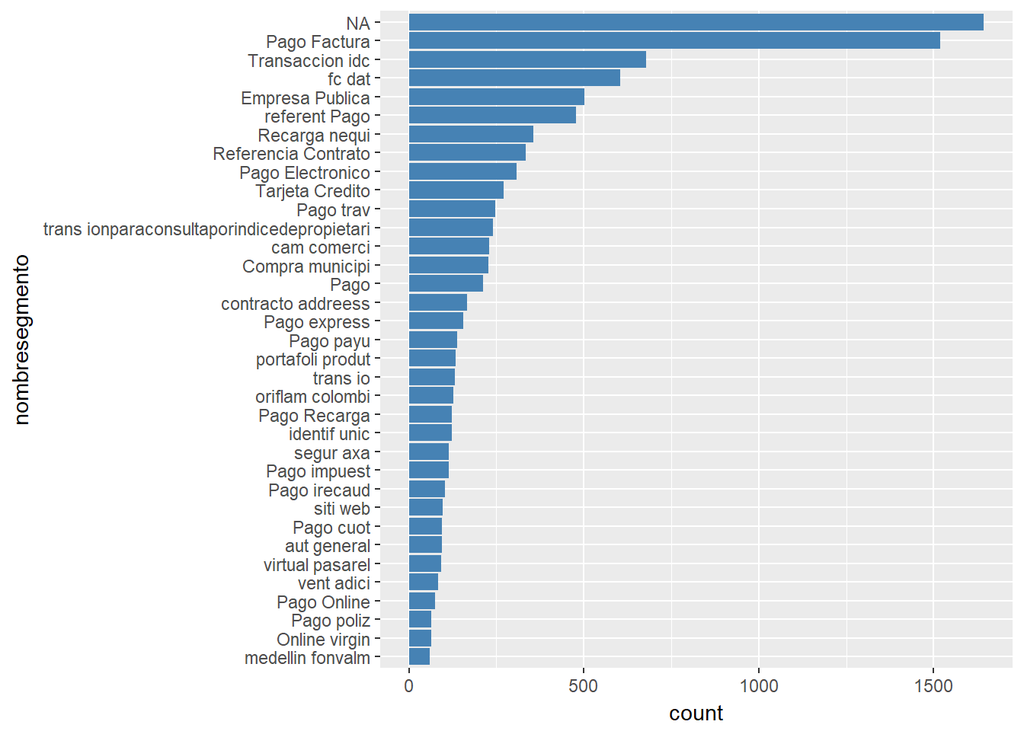

```r
#Consultamos el orden de frecuencia de la muestra. En este caso de mayor a menor.
#Guardamos el orden de los levels en una variable
orden <- names(sort(table(df.comp2_10000$segmentsmall), decreasing=FALSE))

#Convertimos en un factor con los niveles ordenados
df.comp2_10000$nombresegmento<-factor(df.comp2_10000$segmentsmall, levels=orden)

require(ggplot2)
gra.2<-ggplot(data = df.comp2_10000, aes(x=nombresegmento)) + geom_bar(fill= "steelblue", size = 0.1 ) +coord_flip()
gra.2
```